# Calculate pairs of MNIST data set samples

```python
%matplotlib inline
import torch
import torchvision
import torchvision.transforms as transforms
from torchvision.transforms import Resize, ToTensor, Normalize, Compose

import matplotlib.pyplot as plt
import numpy as np

from tqdm.notebook import tqdm
from IPython.display import clear_output

from torch.utils.data import DataLoader
import torch.nn as nn
import seaborn as sns
from collections import defaultdict

# Define which device to use for computations
# If you have gpu, use 'cuda'
device = torch.device('cuda') if torch.cuda.is_available() else torch.device('cpu')
print("{} is used".format(device))
```

```
cpu is used
```

## Task 1. Prepare data for training and model selection

PyTorch torchvision module provides you with some predesigned datasets. Like the MNIST dataset, that we are going to use (https://pytorch.org/vision/0.8/_modules/torchvision/datasets/mnist.html#MNIST). Let us build a simple MNIST dataset and visualise some samples.

For the needs of this project I will have to implement a similar Dataset class which will yield an image pair and a label equal to the mode 10 sum of the labels in the pair.

### MnistPairs dataset

Implement the **getitem** method in the dataset.py file. Build training and test sets with the 'right' and 'left' orders of the digits. Split the both training sets into training and validation sets with 90% and 10% of the data respectively. Concatenate the validation sets into one with both 'right' and 'left' orders. The same should be done with the test sets. Visualise some samples from the constructed datasets.

```python
from dataset import MnistPairs
```

```python
# Define data transforms: converts Images to tensors and normalizes to [-1, 1]

transforms = Compose([ToTensor(),
                      Normalize(mean=(0.5,), std=(0.5,))])

# Load the datasets
train_right_order_dataset = MnistPairs(root='.',
                                      train=True,
                                      download=True,
                                      transform=transforms,
                                      order='right',
                                      return_original_labels=True)

train_left_order_dataset = MnistPairs(root='.',
                                     train=True,
                                     download=True,
                                     transform=transforms,
                                     order='left',
                                     return_original_labels=True)

test_right_order_dataset = MnistPairs(root='.',
                                      train=False,
                                      download=True,
                                      transform=transforms,
                                      order='right',
                                      return_original_labels=True)

test_left_order_dataset = MnistPairs(root='.',
                                     train=False,
                                     download=True,
                                     transform=transforms,
                                     order='left',
                                     return_original_labels=True)


# Put 90percent of training set for training and 10percent for validation
# When debugging one can see that each of sets above count 30'000 samples
split = [27000, 3000]
train_right_order_dataset, validation_right_order = torch.utils.data.random_split(train_right_order_dataset, split)
train_left_order_dataset, validation_left_order = torch.utils.data.random_split(train_left_order_dataset, split)


# Concatenate the validation and test sets together (no right/left order separation)
validation_dataset = torch.utils.data.ConcatDataset((validation_right_order, validation_left_order))
test_dataset = torch.utils.data.ConcatDataset((test_right_order_dataset, test_left_order_dataset))
```

Although not mentioned explicitly on exercise PDF we will visualize some samples from the constructed datasets, as mentioned in the previous text paragraph.

```python
def extract_3_sample_images(data_set):
    """Takes from a given data set 3 samples (the first three) and returns them as a list (concatenated)"""

    list_of_pairs = []
    for index in range(3):
        current_pair = data_set[index]
        first_image = current_pair[0]
        second_image = current_pair[1]
        pair_image = torch.cat((first_image, second_image), 2)  # concatenate to have side by side
        list_of_pairs.append(pair_image)
    list_as_numpy = [t.numpy() for t in list_of_pairs]
    return list_as_numpy


def print_samples(data_set, list_of_samples, dataset_name):
    """Visualizes the list of samples (containing 3) from a dataset """

    fig = plt.figure(figsize=(9, 2.5))
    plt.title(str(dataset_name) + ': Visualization of samples', fontweight='bold', fontsize=18)
    plt.axis('off')
    for i in range(1, 4):
        fig.add_subplot(1, 3, i)
        plt.title('Label: ' + str(data_set[i-1][2]))  # it is modulo 10 (defined in .py file)
        plt.axis('off')
        plt.imshow(list_of_samples[i - 1][0], cmap='gray')
    plt.show()
```

```
Visualization of samples in grayscale, Label is (Label1 + Label2)mod10
```

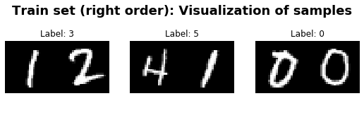

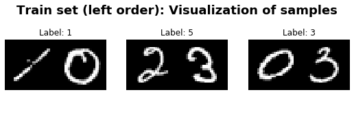

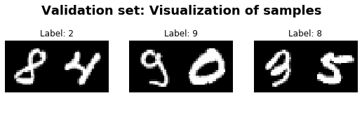

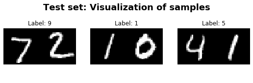

```python
pairs_train_right = extract_3_sample_images(train_right_order_dataset)
pairs_train_left = extract_3_sample_images(train_left_order_dataset)
pairs_validation = extract_3_sample_images(validation_dataset)
pairs_test = extract_3_sample_images(test_dataset)

print('Visualization of samples in grayscale, Label is (Label1 + Label2)mod10 ')

print_samples(train_right_order_dataset, pairs_train_right, 'Train set (right order)')
print_samples(train_left_order_dataset, pairs_train_left, 'Train set (left order)')
print_samples(validation_dataset, pairs_validation, 'Validation set')
print_samples(test_dataset, pairs_test, 'Test set')
```

### Label and Pair Distribution

Visualize the distribution of the labels and pairs in the training, validation and testing sets.

```python
def show_label_distribution(data_set, data_set_name, preferred_visualization):
    """For a given preferred visualization (either bar oder pie chart) the distribution of
    labels contained in the data set will be visualized (depending on the preference)"""

    assert preferred_visualization in ['bars', 'pie'], "Unexpected argument. Expected: \'bars\' or \'pie\'"

    possible_labels = ['0', '1', '2', '3', '4', '5', '6', '7', '8', '9']
    all_labels, amount_of_occurrences = [], []

    for i in range(len(data_set)):
        all_labels.append(data_set[i][2])
    for i in range(0,10):
        amount_of_occurrences.append(all_labels.count(i))

    if preferred_visualization == 'bars':
        figure = plt.figure()
        plt.title(str(data_set_name) + ': Distribution of labels\n', fontweight='bold', fontsize=18)
        plt.barh(possible_labels, amount_of_occurrences)
        plt.ylabel('Amount of occurrences')
        plt.xlabel('Label')
        plt.show()

    if preferred_visualization == 'pie':
        colors = [250, 230, 210, 200, 180, 160, 140, 120, 100, 80]  # grayscale data
        fig1, ax1 = plt.subplots()
        plt.title(str(data_set_name) + ': Distribution of labels\n\n', fontweight='bold', fontsize=18)
        ax1.pie(amount_of_occurrences, labels=possible_labels, autopct='%1.1f%%', startangle=90,
                pctdistance=1.18,  labeldistance=1.38, counterclock=False,
                colors = [str(x/255) for x in colors])
        ax1.axis('equal')
        plt.show()
```

```python
def show_pair_distribution(data_set, ax):
    """For dataset visualizes the distribution of pairs (since an image is a pair of images)"""

    matrix = np.zeros((10,10))  # want all possible combinations of pairs
    label_one, label_two = [], []
    for _, _, _, first_label, second_label in data_set:
        label_one.append(first_label)
        label_two.append(second_label)
    for i, j in zip(label_one, label_two):
        matrix[i,j] = matrix[i, j] + 1  # increase for each occured pair

    sns.heatmap(matrix, annot=False, vmin=0, vmax=360, ax=ax)
```

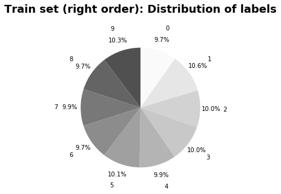

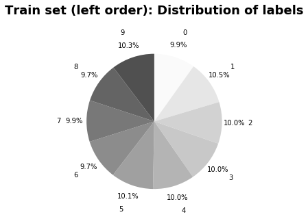

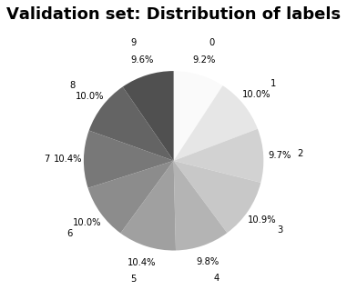

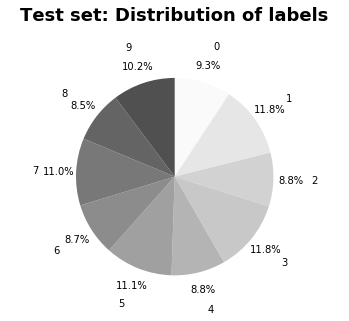

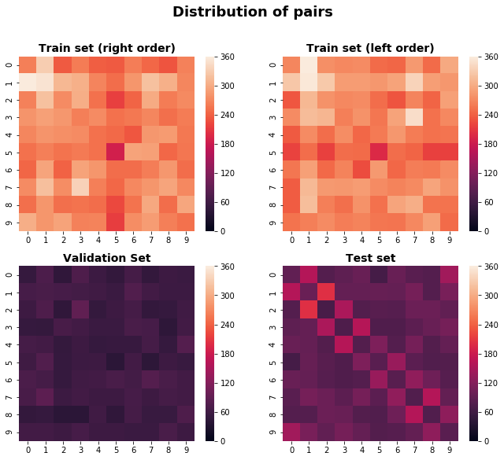

```python
list_of_sets = [train_right_order_dataset, train_left_order_dataset, validation_dataset, test_dataset]
name_of_sets = ['Train set (right order)', 'Train set (left order)', 'Validation Set', 'Test set']


# Label distribution
preferred_visualization = 'pie'

show_label_distribution(train_right_order_dataset, 'Train set (right order)', preferred_visualization)
show_label_distribution(train_left_order_dataset, 'Train set (left order)', preferred_visualization)
show_label_distribution(validation_dataset, 'Validation set', preferred_visualization)
show_label_distribution(test_dataset, 'Test set', preferred_visualization)


# Pair distribution
fig,axn = plt.subplots(2, 2, sharex=False, sharey=False, figsize=(11,9))
fig.suptitle('Distribution of pairs', fontweight='bold', fontsize=18)

for name, (ax, dataset) in enumerate(zip(axn.flat, list_of_sets)):
    ax.set_title(str(name_of_sets[name]), fontsize=14, fontweight='bold')
    show_pair_distribution(dataset, ax)
```

If the distribution of the labels in the test set differs from the one in the training set, we should expect a different performance of the model on the test set.

#### Analysis of visualized distributions

We see in the pie charts (could also use bar charts if desired, change variable preferred_visualization to 'bars') that the distribution of labels is roughly the same in all the different data sets. Overall there are some values that differ a bit more but it is mostly 10%. Some vary a bit more (especially in test set I see that the labels 2, 4, 6 and 8 are lesser than the others.

When considering the heatmaps (as stated on the exercise sheet we should use the same range) we see that obviously the amount of occurences in general differ from the train set to validation and test set. This is no surprise since this ratio is desired (see above, 90% train, 10% validation). Nevertheless we see more of a fluctuating patter in the test dataset where some label pairings seem to occur more often (for example 1,2 and 2,1) since the squares for them are brigther than the majority.

## Task 2. Design training settings

Having the MnistPairs dataset implemented, we can now nicely wrap in with a DataLoader class for the ease of training.

```python
batch_size, num_workers = 64, 0

train_right_dataloader = DataLoader(train_right_order_dataset, batch_size=batch_size,
                                    shuffle=True, num_workers=num_workers)
train_left_dataloader = DataLoader(train_left_order_dataset, batch_size=batch_size,
                                   shuffle=True, num_workers=num_workers)
validation_dataloader = DataLoader(validation_dataset, batch_size=batch_size,
                                   shuffle=True, num_workers=num_workers)
test_dataloader = DataLoader(test_dataset, batch_size=batch_size, shuffle=True, num_workers=num_workers)
```

Define a bunch of models to test, the loss function and the optimizers.

```python
# We have seen similar model creation in tutorial, I use this as inspiration

class Module10ModelOne(nn.Module):
    """Model with 1 hidden layer, 128 hidden neurons, ReLU activation function"""
    def __init__(self):
        super(Module10ModelOne, self).__init__()
        self.main = nn.Sequential(nn.Linear(28*28*2, 128),  # 128 hidden neurons
                                  nn.ReLU(),  # ReLu activation function
                                  nn.Linear(128, 10))  # we got 10 classes as output

    def forward(self, x, y):
        img = torch.cat((x,y), 2)
        out = img.view(img.size(0), 28*28*2)
        out = self.main(out)
        return out


class Module10ModelTwo(nn.Module):
    """Model with 1 hidden layer, 128 hidden neurons, Sigmoid activation function"""
    def __init__(self):
        super(Module10ModelTwo, self).__init__()
        self.main = nn.Sequential(nn.Linear(28*28*2, 128),
                                  nn.Sigmoid(),  # Sigmoid activation function
                                  nn.Linear(128, 10))  # we got 10 classes

    def forward(self, x, y):
        img = torch.cat((x,y), 2)
        out = img.view(img.size(0), 28*28*2)
        out = self.main(out)
        return out


class Module10ModelThree(nn.Module):
    """Model with 2 hidden layers, 128 & 64 hidden neurons, ReLU activation function, Softmax end"""
    def __init__(self):
        super(Module10ModelThree, self).__init__()
        self.main = nn.Sequential(nn.Linear(28*28*2, 128),  # first hidden layer: 128
                                  nn.ReLU(),  # ReLU activation function
                                  nn.Linear(128, 64),  # second hidden layer: 64
                                  nn.ReLU(),  # ReLU activation function
                                  nn.Linear(64, 10), # we got 10 classes
                                  nn.Softmax(dim=1))

    def forward(self, x, y):
        img = torch.cat((x,y), 2)
        out = img.view(img.size(0), 28*28*2)
        out = self.main(out)
        return out
```

Let us also define the metric we are going to use for the assesment of the model. We will simply use the accuracy of the model.

```python
# implemented this but in the end I used the same procedure as discussed in the tutorials

def compute_accuracy(labels, predictions):
    """For a list of all labels from each sample and all predictions for each sample,
    compares them and returns the accuracy"""

    labels, predictions = labels.numpy(), predictions.numpy()  # np arrays for better handling
    correct_predictions = np.sum(labels==predictions)

    return correct_predictions/len(labels)
```

Write the training loop.

```python
def train_model(model, dataloader, optimizer, num_epochs, loss_fn):
    model.train()
    losses = []
    correct_predictions = 0

    for iteration, (first_imgs, second_imgs, labels, _, _) in enumerate(dataloader):
        first_images = first_imgs.to(device)
        second_images = second_imgs.to(device)
        labels = labels.to(device)
        optimizer.zero_grad()
        output = model(first_images, second_images)
        predictions = output.argmax(dim=1)  # argmax gives pred
        loss = loss_fn(output, labels)
        loss.backward()
        optimizer.step()
        losses.append(loss.item())  # with that can keep track of losses per epoch
        correct_predictions += (predictions == labels).sum().item()

    mean_loss = np.array(losses).mean()
    accuracy = correct_predictions / len(dataloader.dataset)

    return mean_loss, accuracy
```

Write the evaluation code.

```python
def evaluate_model(model, data_loader, loss_fn):
    model.eval()
    losses = []
    correct_predictions = 0

    with torch.no_grad():
        for iteration, (first_imgs, second_imgs, labels, _, _) in enumerate(data_loader):
            first_images = first_imgs.to(device)
            second_images = second_imgs.to(device)
            labels = labels.to(device)
            output = model(first_images, second_images)
            predictions = output.argmax(dim=1)
            loss = loss_fn(output, labels)
            losses.append(loss.item())
            correct_predictions += (predictions == labels).sum().item()

    mean_loss = np.array(losses).mean()
    accuracy = correct_predictions / len(data_loader.dataset)

    return mean_loss, accuracy
```

## Task 3. Train on training 'right' set.

Train the models on training 'right' set and select the best model on the validation set.

#### Structure of training part

First I make two helper functions: One for the examination set up for the models and one for the plots. Since I train later the set with a 100 epochs I didn't want for every epoch the loss and accuracy printed. Therefore there is an optional parameter (show_line_output) which could be put as True if one desires to see the output for each epoch.

```python
def examine_model(model, model_name, n_epochs, learning_rate, loss_tuple, optimizer_tuple, train_dataloader,
                  val_dataloader, show_line_output=False):
    """ With given model and specification this will train and evaluate the given sets for each computing
    for each epoch the average loss and accuracy and then invoking a helper function for visualization of
    the obtained values"""

    model = model.to(device)
    losses_train, losses_val, accs_train, accs_val = ([] for i in range(4))

    print('Training of Model ' + str(model_name) + ', Optimizer = ' + str(optimizer_tuple[1])
          + ', Learning rate = ' + str(learning_rate) + '\n-----------')

    for epoch in range(n_epochs):
        loss_train, acc_train = train_model(model, train_dataloader, optimizer_tuple[0], n_epochs, loss_tuple[0])
        losses_train.append(loss_train)
        accs_train.append(acc_train)

        loss_val, acc_val = evaluate_model(model, val_dataloader, loss_tuple[0])
        losses_val.append(loss_val)
        accs_val.append(acc_val)

        # if average loss/accuracy should be printed for each epoch:
        if show_line_output == True:
            print('Epoch {}'.format(epoch+1))
            print('Train average loss: {:.4f}, accuracy: {:.3f}'.format(loss_train, acc_train))
            print('Validation average loss: {:.4f}, accuracy: {:.3f}'.format(loss_val, acc_val))

    plot_metrics(model_name, np.array(learning_rate), np.array(n_epochs),
                 np.array(losses_train), np.array(losses_val),
                 np.array(accs_train), np.array(accs_val),
                 loss_tuple[1], optimizer_tuple[1])

    return
```

```python
def plot_metrics(model_name, learning_rate, n_epochs, losses_train, losses_val, accs_train, accs_val,
                 loss_fct_name, optimizer_name):
    """ With a given model and specifications this method plots the (avg) losses and the accuracy per
    epoch of the training set and the validation set in the same subplot for direct comparison"""

    plt.figure(1, figsize=(15,4.5)).suptitle('Model ' + str(model_name) + ', Epochs: ' + str(n_epochs)
                                             + ', Learning rate: ' + str(learning_rate)
                                             + ', Loss function: ' + str(loss_fct_name)
                                             + ', Optimizer: ' + str(optimizer_name) + '\n',
                                             fontweight='bold', fontsize=18)

    plt.subplot(1,2,1)
    plt.scatter(np.arange(1, n_epochs+1), np.array(losses_train), label='Training')
    plt.scatter(np.arange(1, n_epochs+1), np.array(losses_val), label='Validation')
    plt.title("Average loss per epoch", y=-0.24, fontweight='bold', fontsize=13)
    plt.xlabel('Epoch'); plt.ylabel('Loss')
    plt.legend(); plt.xticks(np.arange(1, n_epochs+1, 10))

    plt.subplot(1,2,2)
    plt.scatter(np.arange(1, n_epochs+1), np.array(accs_train), label='Training')
    plt.scatter(np.arange(1, n_epochs+1), np.array(accs_val), label='Validation')
    plt.title("Average accuracy per epoch", y=-0.24, fontweight='bold', fontsize=13)
    plt.xlabel('Epoch'); plt.ylabel('Accuracy')
    plt.legend(); plt.xticks(np.arange(1, n_epochs+1, 10))

    plt.show()
```

Now applying the previously defined functions in order to examine the defined models

```
Training of Model One, Optimizer = Stochastic Gradient Descent, Learning rate = 0.05
-----------
```

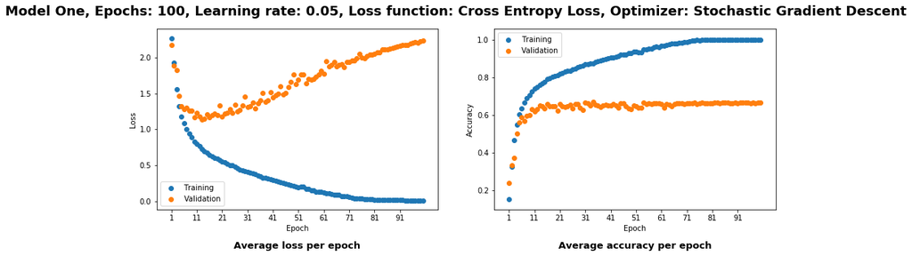

```
Training of Model Two, Optimizer = Adam Algorithm, Learning rate = 0.0005
-----------
```

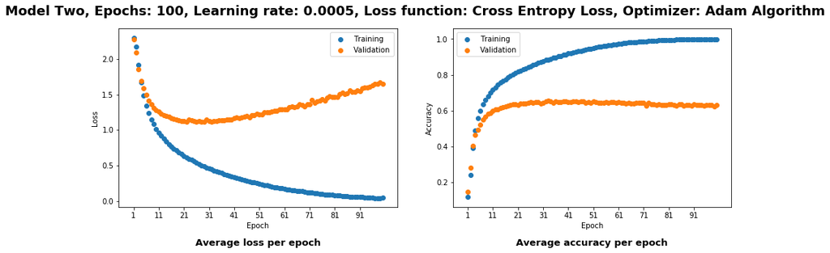

```
Training of Model Three, Optimizer = Stochastic Gradient Descent, Learning rate = 0.1
-----------
```

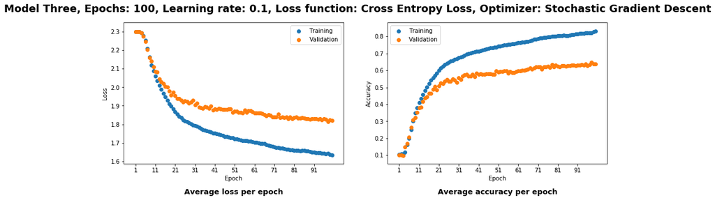

```python
model1 = Module10ModelOne()  # 1 hidden layer, ReLU
model_name1 = 'One'
n_epochs1 = 100
learning_rate1 = 0.05
loss_tuple1 = (torch.nn.CrossEntropyLoss(), 'Cross Entropy Loss')
optimizer_tuple1 = (torch.optim.SGD(model1.parameters(), lr=learning_rate1), 'Stochastic Gradient Descent')

model2 = Module10ModelTwo()  # 1 hidden layer, Sigmoid
model_name2 = 'Two'
n_epochs2 = 100
learning_rate2 = 0.0005
loss_tuple2 = (torch.nn.CrossEntropyLoss(), 'Cross Entropy Loss')
optimizer_tuple2 = (torch.optim.Adam(model2.parameters(), lr=learning_rate2), 'Adam Algorithm')

model3 = Module10ModelThree()  # 2 hidden layers, ReLU
model_name3 = 'Three'
n_epochs3 = 100
learning_rate3 = 0.1
loss_tuple3 = (torch.nn.CrossEntropyLoss(), 'Cross Entropy Loss')
optimizer_tuple3 = (torch.optim.SGD(model3.parameters(), lr=learning_rate3), 'Stochastic Gradient Descent')


examine_model(model1, model_name1, n_epochs1, learning_rate1,
              loss_tuple1, optimizer_tuple1, train_right_dataloader, validation_dataloader)

examine_model(model2, model_name2, n_epochs2, learning_rate2,
              loss_tuple2, optimizer_tuple2, train_right_dataloader, validation_dataloader)

examine_model(model3, model_name3, n_epochs3, learning_rate3,
              loss_tuple3, optimizer_tuple3, train_right_dataloader, validation_dataloader)
```

#### Discussion of the best model here:

The third training set up seems to be the best out of these three. It is the third model with a learning rate of 0.1 and the Stochastic Gradient Descent optimizer. I made this decision when comparing the average loss and accuracy of the validation set with the other's. When comparing the loss in the graphs one can see that the first two are overfitting. The third model has a better behavior also in the acccuracy graph where it isn't stagnating as much as with the others.

## Task 4. Train on concatenated training set.

Train the models on concatenated training set and select the best model on the validation set.

```python
train_dataset = torch.utils.data.ConcatDataset((train_right_order_dataset, train_left_order_dataset))

batch_size, num_workers = 64, 0
train_dataloader = DataLoader(train_dataset, batch_size=batch_size, shuffle=True, num_workers=num_workers)
```

```
Training of Model One, Optimizer = Stochastic Gradient Descent, Learning rate = 0.05
-----------
```

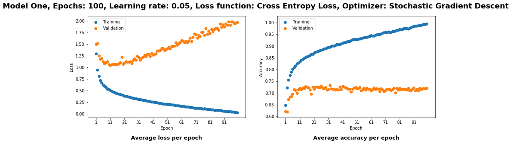

```
Training of Model Two, Optimizer = Adam Algorithm, Learning rate = 0.0005
-----------
```

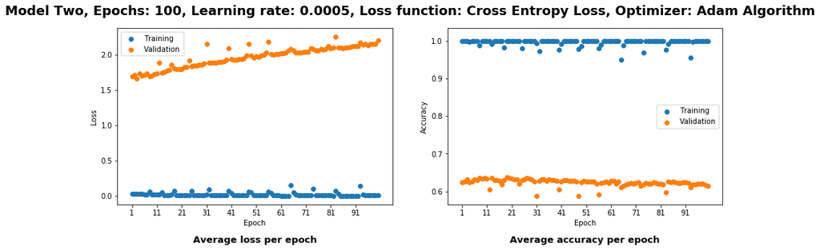

```
Training of Model Three, Optimizer = Stochastic Gradient Descent, Learning rate = 0.1
-----------
```

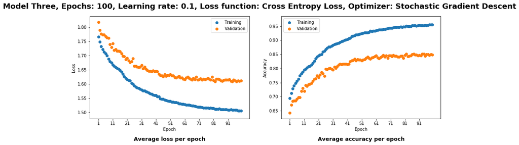

```python
examine_model(model1, model_name1, n_epochs1, learning_rate1,
              loss_tuple1, optimizer_tuple1, train_dataloader, validation_dataloader)
examine_model(model2, model_name2, n_epochs2, learning_rate2,
              loss_tuple2, optimizer_tuple2, train_right_dataloader, validation_dataloader)
examine_model(model3, model_name3, n_epochs3, learning_rate3,
              loss_tuple3, optimizer_tuple3, train_dataloader, validation_dataloader)
```

## Task 5. Evaluation

From the previously selected models select the one that shows the best results on the validation set. Let's denote this as the best model. How can you explain the differences in the accuracies of the models trained on different training sets?

#### Comparison of the two previously selected models

The quality of the model trained on the whole data set (Task 4) is clearly better than the previous one. The reason is the bigger dataset which doubled in quantity and therefore gives the network double as many inputs to learn. Since an epoch is one learning cycle where the learner sees the whole training data set, doubling the training data set yields in a bigger learning cycle. Both, the loss and the accuracy improved on this model with the bigger data set.

Report the accuracy of the best model on the test set.

```python
val_loss, val_acc = evaluate_model(model3, validation_dataloader, loss_tuple3[0])
print('Loss on Validation Set: ' + str(val_loss) + '\tAccuracy on Validation Set: ' + str(val_acc))

test_loss, test_acc = evaluate_model(model3, test_dataloader, loss_tuple3[0])
print('Loss on Test Set: ' + str(test_loss) + '\tAccuracy on Test Set: ' + str(test_acc))
```

```
Loss on Validation Set: 1.6110629997354873	Accuracy on Validation Set: 0.8481666666666666
Loss on Test Set: 1.6068479885720903	Accuracy on Test Set: 0.8536
```

## Task 6. Visualizations

Visualize some examples of the best model's successful and failure predictions on the test set. Visualize the accuaracy depending on the digit pairs. Why is the model better or worse on some digits?

```python
def extract_correct_false_predictions(model, dataloader):
    """Extracts correct and false predictions and stores them into ascending ordered lists"""

    correct_preds, wrong_preds = [], []

    for i, (first_imgs, second_imgs, labels, first_labels, second_labels) in enumerate(dataloader):
        for left_img, right_img, label, right_label, left_label in zip (first_imgs, second_imgs, labels,
                                                                        first_labels, second_labels):
            out = model(left_img.to(device), right_img.to(device))
            cls = out.argmax()
            if cls == label:
                correct_preds.append((out.max().item(), cls.item(), torch.cat((left_img, right_img),2)))
            else:
                wrong_preds.append((out.max().item(), cls.item(), torch.cat((left_img, right_img),2)))

    # sort them into ascending order
    # for example: correct_pred[-1] is the one where the network was the most sure and it is correct
    correct_preds = sorted(correct_preds, key=lambda t: t[0])
    wrong_preds = sorted(wrong_preds, key=lambda t: t[0])

    return correct_preds, wrong_preds
```

```python
def create_dict_pairs_predictions(model, dataloader):
    """For each pair of digits computes the accuracy of its predictions"""

    pairs_prediction_dict = defaultdict(list)

    for i, (first_imgs, second_imgs, labels, first_labels, second_labels) in enumerate(dataloader):
        for left_img, right_img, label, right_label, left_label in zip(first_imgs, second_imgs, labels,
                                                                       first_labels, second_labels):
            out = model(left_img.to(device), right_img.to(device))
            cls = out.argmax()

            # append 0 to pair of digits when prediction is wrong, and 1 if right
            if cls != label:
                pairs_prediction_dict[(right_label.item(),left_label.item())].append(0)
            else:
                pairs_prediction_dict[(right_label.item(),left_label.item())].append(1)

    return pairs_prediction_dict
```

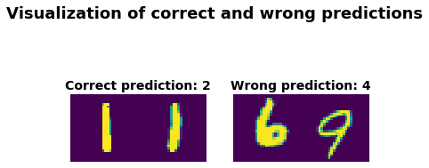

```python
correct_predictions, wrong_predictions = extract_correct_false_predictions(model3, test_dataloader)


plt.figure(1).suptitle('Visualization of correct and wrong predictions', fontweight='bold', fontsize=18)

plt.subplot(1,2,1)
plt.imshow(correct_predictions[-1][2][0])
plt.axis('off')
plt.title('Correct prediction: ' + str(correct_predictions[-1][1]), fontweight='bold', fontsize=14)

plt.subplot(1,2,2)
plt.imshow(wrong_predictions[-1][2][0])
plt.axis('off')
plt.title('Wrong prediction: ' + str(wrong_predictions[-1][1]), fontweight='bold', fontsize=14)

plt.show()
```